# Project: Investigate a Dataset - No Show Appointments

- Introduction
- Data Wrangling
- Exploratory Data Analysis
- Conclusions

## Introduction

### Dataset Description

The No show appointment dataset collects information from over 100k medical appointments in Brazil, seeking to determine whether or not a patient show up for their appointment.

Each record has information characterizing a particular patient as described below:

- PatientId - A unique identifier for the patient
- AppointmentID - a unique identifier for the appointment
- Gender - gender of the patient, indicated F for female and M for male
- ScheduledDay - day the patient is scheduled for their appointment
- Age - age of the patient
- Neighbourhood - location of the hospital
- Scholarship - whether or not the patient is enrolled in Brasilian welfare program Bolsa Família
- Hipertension - whether or not the patient is hypertensive
- Diabetes - whether or not the patient is diabetic
- Alcoholism - whether or not the patient is an alcoholic
- SMS_received - whether or not the patient received an sms
- No-show - whether or not the patient showed up for their appointment; No if they showed up and Yes if they didn't

This dataset can be found in kaggle using this [link](https://www.kaggle.com/datasets/ashank19/no-show-appointments-kaggle)

### Question(s) for Analysis

This analysis seeks to answer the following questions:

1. Is there a relationship between Age and No show?
2. Is there a relationship between gender and No show?
3. Does the day of week of the appointment affect No show?
4. What's the relation of hospital location and No show?
5. Does scholarship, hypertension, diabetes, alcoholism and sms_received affect No show?
6. What's the trend of no show across the months?

```python
import numpy as np
import pandas as pd
import seaborn as sns
import matplotlib.pyplot as plt
%matplotlib inline
sns.set_theme(style = 'darkgrid')
```

```python
pd.__version__
```

```
'1.2.4'
```

## Data Wrangling

```python
# loading the data and displaying the first 5 rows
df = pd.read_csv('noshowappointments-kagglev2-may-2016.csv')
df.head()
```

|  | PatientId | AppointmentID | Gender | ScheduledDay | AppointmentDay | Age | Neighbourhood | Scholarship | Hipertension | Diabetes | Alcoholism | Handcap | SMS_received | No-show |
| --- | --- | --- | --- | --- | --- | --- | --- | --- | --- | --- | --- | --- | --- | --- |
| 0 | 2.987250e+13 | 5642903 | F | 2016-04-29T18:38:08Z | 2016-04-29T00:00:00Z | 62 | JARDIM DA PENHA | 0 | 1 | 0 | 0 | 0 | 0 | No |
| 1 | 5.589978e+14 | 5642503 | M | 2016-04-29T16:08:27Z | 2016-04-29T00:00:00Z | 56 | JARDIM DA PENHA | 0 | 0 | 0 | 0 | 0 | 0 | No |
| 2 | 4.262962e+12 | 5642549 | F | 2016-04-29T16:19:04Z | 2016-04-29T00:00:00Z | 62 | MATA DA PRAIA | 0 | 0 | 0 | 0 | 0 | 0 | No |
| 3 | 8.679512e+11 | 5642828 | F | 2016-04-29T17:29:31Z | 2016-04-29T00:00:00Z | 8 | PONTAL DE CAMBURI | 0 | 0 | 0 | 0 | 0 | 0 | No |
| 4 | 8.841186e+12 | 5642494 | F | 2016-04-29T16:07:23Z | 2016-04-29T00:00:00Z | 56 | JARDIM DA PENHA | 0 | 1 | 1 | 0 | 0 | 0 | No |

```python
# number of rows and columns in the dataset
print('The dataframe has', df.shape[0], 'rows and ', df.shape[1], 'columns')
```

```
The dataframe has 110527 rows and  14 columns
```

```python
# Summary information about the dataframe
df.info()
```

```
<class 'pandas.core.frame.DataFrame'>
RangeIndex: 110527 entries, 0 to 110526
Data columns (total 14 columns):
 #   Column          Non-Null Count   Dtype
---  ------          --------------   -----
 0   PatientId       110527 non-null  float64
 1   AppointmentID   110527 non-null  int64
 2   Gender          110527 non-null  object
 3   ScheduledDay    110527 non-null  object
 4   AppointmentDay  110527 non-null  object
 5   Age             110527 non-null  int64
 6   Neighbourhood   110527 non-null  object
 7   Scholarship     110527 non-null  int64
 8   Hipertension    110527 non-null  int64
 9   Diabetes        110527 non-null  int64
 10  Alcoholism      110527 non-null  int64
 11  Handcap         110527 non-null  int64
 12  SMS_received    110527 non-null  int64
 13  No-show         110527 non-null  object
dtypes: float64(1), int64(8), object(5)
memory usage: 11.8+ MB
```

There are no null values in the dataframe

```python
# checking for duplicates
num_duplicates = df.duplicated().sum()
print('The dataframe has', num_duplicates, 'duplicated rows')
```

```
The dataframe has 0 duplicated rows
```

```python
# percentage of patients who showed up
df['No-show'].value_counts(normalize=True)
```

```
No     0.798067
Yes    0.201933
Name: No-show, dtype: float64
```

```python
# Summary statistics
df.describe()
```

|  | PatientId | AppointmentID | Age | Scholarship | Hipertension | Diabetes | Alcoholism | Handcap | SMS_received |
| --- | --- | --- | --- | --- | --- | --- | --- | --- | --- |
| count | 1.105270e+05 | 1.105270e+05 | 110527.000000 | 110527.000000 | 110527.000000 | 110527.000000 | 110527.000000 | 110527.000000 | 110527.000000 |
| mean | 1.474963e+14 | 5.675305e+06 | 37.088874 | 0.098266 | 0.197246 | 0.071865 | 0.030400 | 0.022248 | 0.321026 |
| std | 2.560949e+14 | 7.129575e+04 | 23.110205 | 0.297675 | 0.397921 | 0.258265 | 0.171686 | 0.161543 | 0.466873 |
| min | 3.921784e+04 | 5.030230e+06 | -1.000000 | 0.000000 | 0.000000 | 0.000000 | 0.000000 | 0.000000 | 0.000000 |
| 25% | 4.172614e+12 | 5.640286e+06 | 18.000000 | 0.000000 | 0.000000 | 0.000000 | 0.000000 | 0.000000 | 0.000000 |
| 50% | 3.173184e+13 | 5.680573e+06 | 37.000000 | 0.000000 | 0.000000 | 0.000000 | 0.000000 | 0.000000 | 0.000000 |
| 75% | 9.439172e+13 | 5.725524e+06 | 55.000000 | 0.000000 | 0.000000 | 0.000000 | 0.000000 | 0.000000 | 1.000000 |
| max | 9.999816e+14 | 5.790484e+06 | 115.000000 | 1.000000 | 1.000000 | 1.000000 | 1.000000 | 4.000000 | 1.000000 |

```python
df.query('Age < 0')
```

|  | PatientId | AppointmentID | Gender | ScheduledDay | AppointmentDay | Age | Neighbourhood | Scholarship | Hipertension | Diabetes | Alcoholism | Handcap | SMS_received | No-show |
| --- | --- | --- | --- | --- | --- | --- | --- | --- | --- | --- | --- | --- | --- | --- |
| 99832 | 4.659432e+14 | 5775010 | F | 2016-06-06T08:58:13Z | 2016-06-06T00:00:00Z | -1 | ROMÃO | 0 | 0 | 0 | 0 | 0 | 0 | No |

This record will be dropped, since there's no appropriate way to encode it.

```python
# Exploring values of the handcap column
df['Handcap'].unique()
```

```
array([0, 1, 2, 3, 4])
```

There being no clear description on the encoding of Handcap column, it will be dropped in this analysis.

### Data Cleaning

In this step, we'll perform the following operations:

- Drop Handcap, PatientId and AppointmentId columns
- Convert ScheduledDay and AppointmentDay columns to datetime
- Rename the columns appropriately
- Drop the record with age of -1

```python
# dropping handcap column
df.drop(columns=['Handcap', 'PatientId', 'AppointmentID'], axis = 1, inplace= True)
```

```python
# converting columns with timestamps from string to datetime
df['ScheduledDay'] = pd.to_datetime(df['ScheduledDay'])
df['AppointmentDay'] = pd.to_datetime(df['AppointmentDay'])

# renaming the columns
col_names = ['gender', 'scheduled_day', 'appointment_day', 'age',
'neighbourhood', 'scholarship', 'hypertension', 'diabetes', 'alcoholism', 'sms_received', 'no_show']
df.columns = col_names

# final datatypes
df.dtypes
```

```
gender                          object
scheduled_day      datetime64[ns, UTC]
appointment_day    datetime64[ns, UTC]
age                              int64
neighbourhood                   object
scholarship                      int64
hypertension                     int64
diabetes                         int64
alcoholism                       int64
sms_received                     int64
no_show                         object
dtype: object
```

```python
df.drop(df[df['age'] == -1].index, inplace = True)
# df['age'].min()
```

## Exploratory Data Analysis

### Q1. What are the general characteristics of those who showed up vs those who didn't?

To get better summary statistics, we'll spit the dataframe into two, separating the no show appointments and those who showed up.

```python
df_show = df.query('no_show == "No"')
df_no_show = df.query('no_show == "Yes"')
```

```python
# descriptive statistics for those who showed up
df_show.describe()
```

|  | age | scholarship | hypertension | diabetes | alcoholism | sms_received |
| --- | --- | --- | --- | --- | --- | --- |
| count | 88207.000000 | 88207.000000 | 88207.000000 | 88207.000000 | 88207.000000 | 88207.000000 |
| mean | 37.790504 | 0.093904 | 0.204394 | 0.073838 | 0.030417 | 0.291337 |
| std | 23.338645 | 0.291697 | 0.403261 | 0.261508 | 0.171733 | 0.454381 |
| min | 0.000000 | 0.000000 | 0.000000 | 0.000000 | 0.000000 | 0.000000 |
| 25% | 18.000000 | 0.000000 | 0.000000 | 0.000000 | 0.000000 | 0.000000 |
| 50% | 38.000000 | 0.000000 | 0.000000 | 0.000000 | 0.000000 | 0.000000 |
| 75% | 56.000000 | 0.000000 | 0.000000 | 0.000000 | 0.000000 | 1.000000 |
| max | 115.000000 | 1.000000 | 1.000000 | 1.000000 | 1.000000 | 1.000000 |

```python
# descriptive statistics for those who didn't show up for appointment
df_no_show.describe()
```

|  | age | scholarship | hypertension | diabetes | alcoholism | sms_received |
| --- | --- | --- | --- | --- | --- | --- |
| count | 22319.000000 | 22319.000000 | 22319.000000 | 22319.000000 | 22319.000000 | 22319.000000 |
| mean | 34.317667 | 0.115507 | 0.169004 | 0.064071 | 0.030333 | 0.438371 |
| std | 21.965941 | 0.319640 | 0.374764 | 0.244885 | 0.171505 | 0.496198 |
| min | 0.000000 | 0.000000 | 0.000000 | 0.000000 | 0.000000 | 0.000000 |
| 25% | 16.000000 | 0.000000 | 0.000000 | 0.000000 | 0.000000 | 0.000000 |
| 50% | 33.000000 | 0.000000 | 0.000000 | 0.000000 | 0.000000 | 0.000000 |
| 75% | 51.000000 | 0.000000 | 0.000000 | 0.000000 | 0.000000 | 1.000000 |
| max | 115.000000 | 1.000000 | 1.000000 | 1.000000 | 1.000000 | 1.000000 |

The mean age of those who didn't show up for the appointment is 34 years.

For this group of patients also, most were not hypertensive, alcoholic or diabetic.

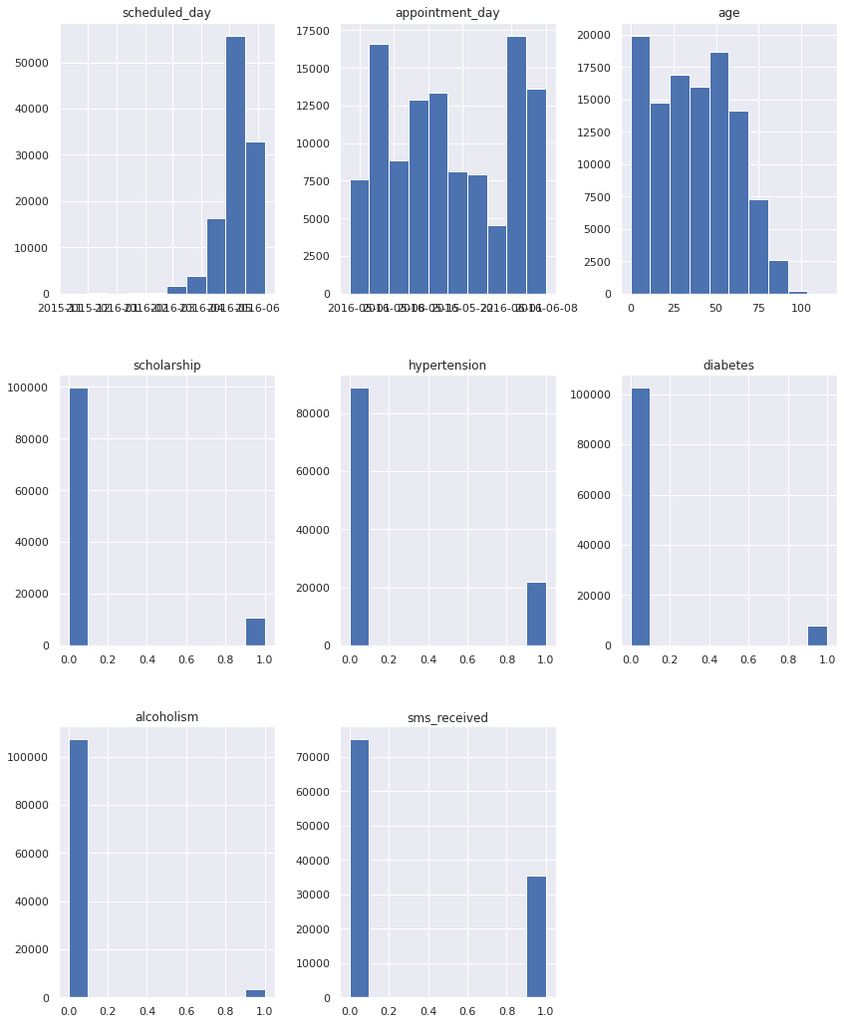

```python
# distribution of the features
df.hist(figsize=(14,18));
```

### Q2. Does Age have any relationship with No Show?

To determine this we'll:

- categorize the ages as per the standard age classification and visualize their distribution
- compare the age categories to No show

Using the general age category structure:

- 0-14 : Children
- 15-24 : Youths
- 25-64 : Adults
- Above 65 : Seniors

We'll categorize the age column and visualize the results.

```python
# Categorizing ages

def categorize_age(age):
    if age < 15:
        category = 'Child'
    elif age < 25:
        category = 'Youth'
    elif age < 65:
        category = 'Adult'
    else:
        category = 'Senior'
    return category

# creating a new column for age categories
df['age_group'] = df['age'].apply(categorize_age)
df.head(2)
```

|  | gender | scheduled_day | appointment_day | age | neighbourhood | scholarship | hypertension | diabetes | alcoholism | sms_received | no_show | age_group |
| --- | --- | --- | --- | --- | --- | --- | --- | --- | --- | --- | --- | --- |
| 0 | F | 2016-04-29 18:38:08+00:00 | 2016-04-29 00:00:00+00:00 | 62 | JARDIM DA PENHA | 0 | 1 | 0 | 0 | 0 | No | Adult |
| 1 | M | 2016-04-29 16:08:27+00:00 | 2016-04-29 00:00:00+00:00 | 56 | JARDIM DA PENHA | 0 | 0 | 0 | 0 | 0 | No | Adult |

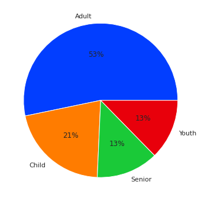

```python
# Count of number of patients in each age group
age_count = df['age_group'].value_counts(normalize=True)
age_labels = df['age_group'].unique()

# generating pie chart for the result
plt.figure(figsize = (8,6))
plt.pie(age_count, labels = age_labels, colors = sns.color_palette('bright'), autopct='%.0f%%');
```

Adults constitute the majority of the population, followed by children.

Since the adults are almost half of the population in the data, visualizing the count based on the no_show column might skew our observations. Therefore, to check the relation between no_show and age, we'll use ratios in each category based on the value of no_show.

```python
# A dataframe for ratios of each age group against no show value
age_noshow = pd.crosstab(df['age_group'], df['no_show'], normalize='index')
age_noshow
```

| no_show age_group | No | Yes |
| --- | --- | --- |
| Adult | 0.802572 | 0.197428 |
| Child | 0.788193 | 0.211807 |
| Senior | 0.844952 | 0.155048 |
| Youth | 0.747323 | 0.252677 |

```python
# age_noshow.index
```

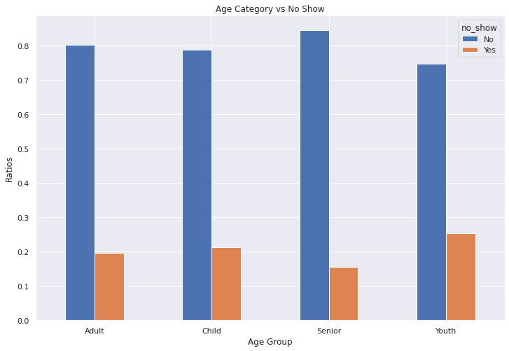

```python
# grouped barplot for age categories
age_noshow.plot.bar(rot=0, figsize = (12,8));
plt.title('Age Category vs No Show');
plt.ylabel('Ratios');
plt.xlabel('Age Group');
```

### Q3. Does Gender have an effect on No show?

To ascertain this, we'll visualize the ratio of male and females who showed up vs those who didn't for the appointments

```python
# Number of males and females in the dataset
print(df['gender'].value_counts(), '\n')

# Percentage composition
gender_pctg = df['gender'].value_counts(normalize=True)

print('{:.0f}% of the patients in our dataset are females, while males are {:.0f}%'.format(gender_pctg[0]*100, gender_pctg[1]*100))
```

```
F    71839
M    38687
Name: gender, dtype: int64

65% of the patients in our dataset are females, while males are 35%
```

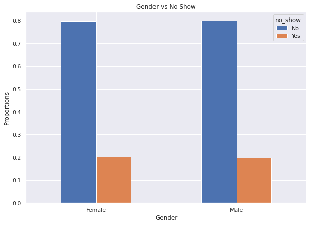

```python
# dataframe of number of patients per gender against no show
gender_crosstab = pd.crosstab(df['gender'], df['no_show'], normalize = 'index')
gender_crosstab.index= ['Female', 'Male']

# bar chart
gender_crosstab.plot.bar(rot = 0, figsize=(10,7));
plt.title('Gender vs No Show');
plt.xlabel('Gender');
plt.ylabel('Proportions');
```

From the graph above, the ratio of males and females by no-show is almost equal, with a very minimal difference.

This narrow margin of difference makes it impractical to conclude that gender of the patients had an influence on no show

### Q4. Does the day of week of the appointment affect No show?

We'll introduce a new column that shows the day of the week a patient was scheduled for appointment and see whether the days have any relation to whether or not they showed up for appointment.

```python
# getting day of week for the appointment
df['appointment_day_of_week'] = df['appointment_day'].apply(lambda x: x.day_name())

# ordering the days to Monday-Sunday
df['appointment_day_of_week'] = pd.Categorical(df['appointment_day_of_week'], categories=
    ['Monday','Tuesday','Wednesday','Thursday','Friday','Saturday', 'Sunday'],
    ordered=True)

# summary counts
count_by_days = df.groupby(['appointment_day_of_week','no_show'])['no_show'].count()
# df['appointment_day_of_week'].value_counts()

# sorting the days from Monday to Sunday
count_by_days.sort_index(inplace = True)
count_by_days
```

```
appointment_day_of_week  no_show
Monday                   No         18024
                         Yes         4690
Tuesday                  No         20488
                         Yes         5152
Wednesday                No         20774
                         Yes         5093
Thursday                 No         13909
                         Yes         3338
Friday                   No         14982
                         Yes         4037
Saturday                 No            30
                         Yes            9
Sunday                   No             0
                         Yes            0
Name: no_show, dtype: int64
```

Most appointments were made on Tuesday and Wednesday

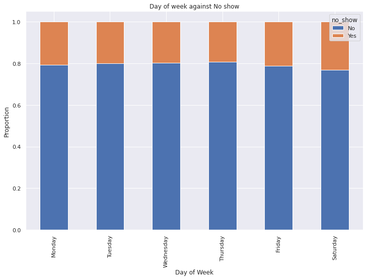

```python
# stacked bar plot for day of week vs no show
weekday_grouped = pd.crosstab(df['appointment_day_of_week'], df['no_show'], normalize='index')
weekday_grouped.plot(kind='bar', stacked=True, figsize = (12,8))
plt.title('Day of week against No show');
plt.ylabel('Proportion');
plt.xlabel('Day of Week');
```

From Monday to Thursday, the percentage of patients who showed up for appointments stagnated at approximately 80%. However, on Friday and Saturday, the proportion of patients who didnt show up slightly increased.

### Q5. Which Neighbourhoods have the highest number of patients showing up?

```python
# number of neighbourhoods in the dataset
df['neighbourhood'].nunique()
```

```
81
```

```python
# new dataframe with No show values summed across locations
location_grouped = pd.crosstab(df['neighbourhood'], df['no_show'])

# column for total count in a given neighbourhood
location_grouped['Total'] = location_grouped['No'] + location_grouped['Yes']
location_grouped.sort_values(by = 'Total', ascending = False, inplace = True)
location_grouped.head()
```

| no_show neighbourhood | No | Yes | Total |
| --- | --- | --- | --- |
| JARDIM CAMBURI | 6252 | 1465 | 7717 |
| MARIA ORTIZ | 4586 | 1219 | 5805 |
| RESISTÊNCIA | 3525 | 906 | 4431 |
| JARDIM DA PENHA | 3246 | 631 | 3877 |
| ITARARÉ | 2591 | 923 | 3514 |

Generally, Jardim Camburi, Maria Ortiz, Resistencia and Jardim Da Penha neighbourhoods had the highest number of appoitments

```python
# locations with highest proportions of patients who showed up
location_grouped['pctg_show'] = location_grouped['No'] / (location_grouped['No'] + location_grouped['Yes'])
location_grouped.sort_values(by = 'pctg_show', ascending = False, inplace = True)
location_grouped.head(3)
```

| no_show neighbourhood | No | Yes | Total | pctg_show |
| --- | --- | --- | --- | --- |
| PARQUE INDUSTRIAL | 1 | 0 | 1 | 1.000000 |
| ILHA DO BOI | 32 | 3 | 35 | 0.914286 |
| AEROPORTO | 7 | 1 | 8 | 0.875000 |

Neighbourhoods with minimal number of appointments had the highest proportions of patients showing up

### Q6. How do scholarship, hypertension, diabetes, alcoholism and sms_received affect No show?

For these categorical variables, we'll visualize their groupings by no show values using combined bar plots.

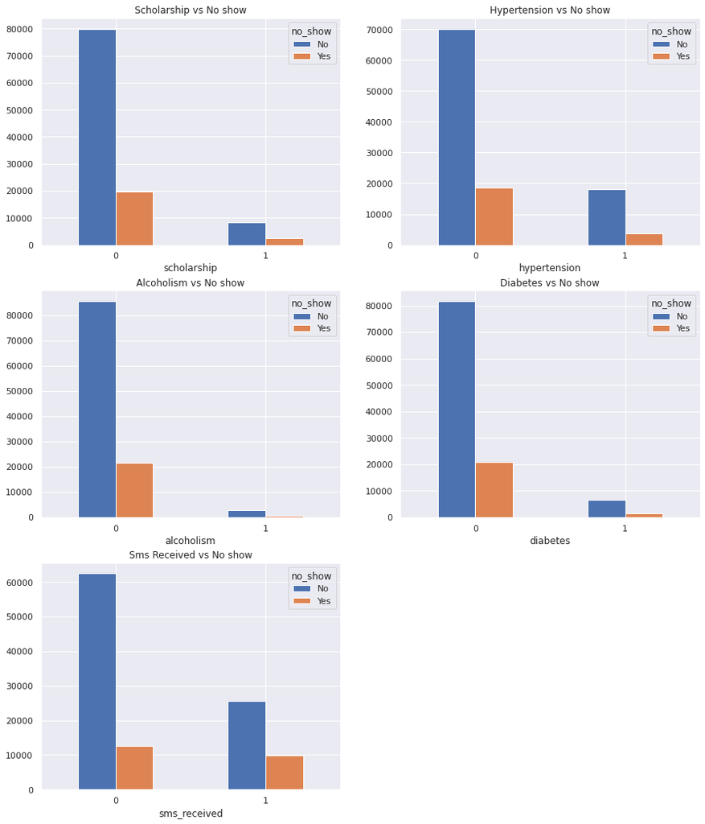

```python
# Visualizing all the stated features in subplots
fig = plt.figure(figsize= (15,18))
ax1 = fig.add_subplot(3, 2, 1)
ax2 = fig.add_subplot(3, 2, 2)
ax3 = fig.add_subplot(3, 2, 3)
ax4 = fig.add_subplot(3, 2, 4)
ax5 = fig.add_subplot(3, 2, 5)
# ax6 = fig.add_subplot(3, 2, 6)

df.groupby('scholarship')['no_show'].value_counts().unstack(level=-1).plot(kind = 'bar', ax = ax1, rot = 0, title = 'Scholarship vs No show');

df.groupby('hypertension')['no_show'].value_counts().unstack(level=-1).plot(kind = 'bar', ax = ax2, rot = 0, title = 'Hypertension vs No show');
df.groupby('alcoholism')['no_show'].value_counts().unstack(level=-1).plot(kind = 'bar', ax = ax3, rot = 0, title = 'Alcoholism vs No show');
df.groupby('diabetes')['no_show'].value_counts().unstack(level=-1).plot(kind = 'bar', ax = ax4, rot = 0, title = 'Diabetes vs No show');
df.groupby('sms_received')['no_show'].value_counts().unstack(level=-1).plot(kind = 'bar', ax = ax5, rot = 0, title = 'Sms Received vs No show');
# df.groupby('handicap')['no_show'].value_counts().unstack(level=-1).plot(kind = 'bar', ax = ax6, rot = 0, title = 'Handicapped vs No show');


plt.show()
```

As stated earlier, majority of patients who showed up:

- were not diabetic
- were not hypertensive
- were not alcoholic
- were not enrolled in the Brazilian welfare program
- did not receive an sms

### Correlations

##### Correlation amongst the variables

This step will help us identify the most appropriate pairs of variables to check against no show.

```python
# copy of the original dataframe
df2 = df.copy()

# function to encode categorical columns of interest
def encode_col(col_list):
    for col in col_list:
        df2[str(col)+'_category'] = df2[col].astype('category').cat.codes
    return df2

# encoding no_show, gender and age category columns
categorical_colums = ['no_show', 'age_group', 'gender']
encode_col(categorical_colums)

# first 2 records of the new dataframe
df2.head(2)
```

|  | gender | scheduled_day | appointment_day | age | neighbourhood | scholarship | hypertension | diabetes | alcoholism | sms_received | no_show | age_group | appointment_day_of_week | no_show_category | age_group_category | gender_category |
| --- | --- | --- | --- | --- | --- | --- | --- | --- | --- | --- | --- | --- | --- | --- | --- | --- |
| 0 | F | 2016-04-29 18:38:08+00:00 | 2016-04-29 00:00:00+00:00 | 62 | JARDIM DA PENHA | 0 | 1 | 0 | 0 | 0 | No | Adult | Friday | 0 | 0 | 0 |
| 1 | M | 2016-04-29 16:08:27+00:00 | 2016-04-29 00:00:00+00:00 | 56 | JARDIM DA PENHA | 0 | 0 | 0 | 0 | 0 | No | Adult | Friday | 0 | 0 | 1 |

```python
df2.columns
```

```
Index(['gender', 'scheduled_day', 'appointment_day', 'age', 'neighbourhood',
       'scholarship', 'hypertension', 'diabetes', 'alcoholism', 'sms_received',
       'no_show', 'age_group', 'appointment_day_of_week', 'no_show_category',
       'age_group_category', 'gender_category'],
      dtype='object')
```

```python
# columns to correlate
cols = ['scholarship', 'hypertension', 'diabetes', 'alcoholism', 'sms_received',
       'no_show_category', 'age_group_category', 'gender_category']

corr_df = df2[cols].corr().stack().reset_index()

# renaming columns of the correlation df
corr_df.columns = ['feature1', 'feature2', 'correlation']

# extract only correlations between a feature and other features
corr_df = corr_df.query('correlation != 1')
corr_df.sort_values(by = 'correlation', ascending = False, inplace = True)
```

```python
# Top 3 positively correlated variables
corr_df.head(6)
```

|  | feature1 | feature2 | correlation |
| --- | --- | --- | --- |
| 10 | hypertension | diabetes | 0.433085 |
| 17 | diabetes | hypertension | 0.433085 |
| 44 | no_show_category | sms_received | 0.126428 |
| 37 | sms_received | no_show_category | 0.126428 |
| 59 | gender_category | alcoholism | 0.106166 |
| 31 | alcoholism | gender_category | 0.106166 |

Hypertension and diabetes have a moderately high positive correlation, meaning that most patients in the dataset who are diabetic are also hypertensive.

```python
# Negatively correlated variables
corr_df.tail(6)
```

|  | feature1 | feature2 | correlation |
| --- | --- | --- | --- |
| 15 | hypertension | gender_category | -0.055722 |
| 57 | gender_category | hypertension | -0.055722 |
| 51 | age_group_category | alcoholism | -0.094611 |
| 30 | alcoholism | age_group_category | -0.094611 |
| 7 | scholarship | gender_category | -0.114296 |
| 56 | gender_category | scholarship | -0.114296 |

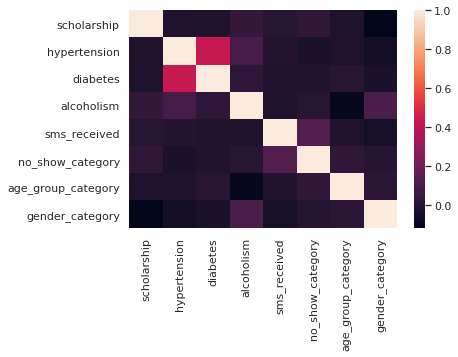

```python
# Visual of the correlations
sns.heatmap(df2[cols].corr());
```

##### Correlation between feature variables and target variable

```python
# correlation between the independent variables and the target variable

df2[cols].corr()['no_show_category'][:]
```

```
scholarship           0.029134
hypertension         -0.035704
diabetes             -0.015181
alcoholism           -0.000197
sms_received          0.126428
no_show_category      1.000000
age_group_category    0.021285
gender_category      -0.004122
Name: no_show_category, dtype: float64
```

### Multivariate Analysis

Using the insights from the correlations above, in this step, we seek to explore how diabetes and hypertension relate to no show

#### Q7. How does diabetes and hypertension impact no show?

```python
df.groupby(['diabetes', 'hypertension', 'no_show'])['no_show'].count()
```

```
diabetes  hypertension  no_show
0         0             No         69010
                        Yes        18258
          1             No         12684
                        Yes         2631
1         0             No          1168
                        Yes          289
          1             No          5345
                        Yes         1141
Name: no_show, dtype: int64
```

Majority of the patients who were neither diabetic nor hypertensive showed up for appointments

### Q7. What's the trend of No show across the months?

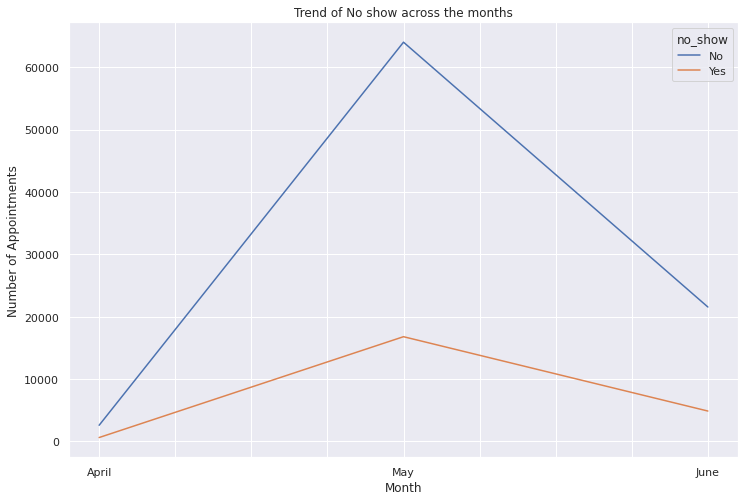

```python
df3 = df.copy()

# Extracting month from the appointment dates
df3['Month'] = df3['appointment_day'].apply(lambda x: x.strftime('%B'))

# correcting order of month
df3['Month'] = pd.Categorical(df3['Month'], categories = ['April', 'May', 'June'], ordered=True)

# trend line
monthly_data = df3.groupby(['Month','no_show'])['no_show'].count()

monthly_data.unstack().plot(figsize = (12,8));
plt.title('Trend of No show across the months');
plt.ylabel('Number of Appointments');
plt.xlabel('Month');
```

The number of patients who showed up for appointments were generally higher than those who didn't, across the months.

The month of May experienced an increase in number of appointments

```python
# feature_cols = ['scholarship', 'hypertension', 'diabetes', 'alcoholism', 'handicap', 'sms_received',
#        'age_category', 'age_group', 'gender_category']
# target_col = df2['no_show_category']
# pd.plotting.scatter_matrix(df2[feature_cols], c=target_col, figsize=(15, 15), marker='o',
#                                  alpha=.8);
```

## Conclusions

In conclusion, 20% of the patients dis not show up for their appointments

#### Limitations

The dataset had a few limitations.

Firstly,there was no clear description in the data source on how the 'Handicap' column was encoded, making it difficult to analyse and draw conclusions on no show

The data is highly skewed on majority of the encoded columns, such as scholarship and alcoholism

More information could be provided to support the neighbourhood variable, such as proximity to the health centres.

```python
from subprocess import call
call(['python3', '-m', 'nbconvert', 'Investigate_a_Dataset.ipynb'])
```

```
1
```